# Super-Advanced R: Package Building

Gregor Passolt

Thursday, May 29, 2014

# Topics

- Why Build Packages
- Package Basics
- Structure of a Package
- Documenting Your Code
- Building
- Checking
- When to Build a Package

# Motivation: Why Build a Package?

# Why make packages?

- Altruism
- Portability
- Pride
- Documentation
- Doing a favor for your future self
- Laziness in all of the above

# Why not make a package?

- Your project isn’t suited for a package.
- Laziness.

Though the newest tools make it pretty darn easy.

# Keeping yourself straight with the snarks

The R-Help mailing list is notorious for being somewhat unfriendly, and being nitpicky when anyone calls a *package* a *library*.

A *library* is a directory where you keep your packages. See `.libPaths()`

A *package* is a collection of files in a particular structure: R files, documentation files, and system files.

# Structure of a package

Open up the folder (or one of the folders) you see in `.libPaths()` and open a package.

```r
.libPaths()
```

```
## [1] "C:/Program Files/R/R-3.1.0/library"
```

Every package is named by its directory. You can also look at packages on the unofficial CRAN mirror on Github.

# Resources for Package Building

- Hadley’s Advanced R Book has a very nice introduction to building packages. This is also the best source I know for `roxygen2` documentation.
- The [Writing R Extensions](http://cran.r-project.org/doc/manuals/R-exts.html) webpage is the definitive source. I wouldn’t advise looking at it except to answer precise, scoped questions.
- RStudio also has a [package basics](http://www.rstudio.com/ide/docs/packages/overview) page, it’s lightweight and focused on the GUI options in RStudio, but has links to more sources as well.

# Contents of a package

At a minimum, the package folder must contain files called `DESCRIPTION` and `NAMESPACE`. These are text files with *no file extension*. They have strict formatting guidelines. `devtools`/`roxygen2` will take care of `NAMESPACE` entirely and give us a pretty good start on `DESCRIPTION`.

Then there are folders, at a minimum one called `R`—where you put your R code, and one called `man` for documentation.

Certain other files and folders are optional, but can be helpful. Common examples are a `NEWS` file to record changes, or a `LICENSE` file if you need to include a copy of your license, or a `src` directory containing code that needs to be compiled (e.g., C++ or FORTRAN).

# Creating a package

The basic steps for making a packge from scratch are:

- Create the file structure (use `devtools::create` or `File/New Project/Package` in a newer version of RStudio; `utils::package.skeleton()` seems dated)
- Put your R code in the R directory
- Create documentation (use `roxygen2::roxygenize` or `devtools::document`)
- Update DESCRIPTION as necessary
- Load and debug (`devtools::load_all` or RStudio button)
- Build the package (`R CMD BUILD` or `devtools::build` or the Build tab in RStudio) (when ready for distribution)
- Check—must pass check to go on CRAN (`R CMD CHECK` or `devtools::check`)

# Packaging

# Truly Minimal Package

Set your working directory as you like and run the following code (let’s go one line at time, together)

- `devtools::create("demo1")`
- `roxygen2::roxygenize("demo1")`
- `devtools::build("demo1")`

This package doesn’t even have any functions! Run `devtools::check("demo1")` and we get one warning, about the non-standard format of the license in the description file.

Change that line in the description file to

```
License: GPL-2
```

then you can build and check again, and it should pass with flying colors!

# Roxygen2 Rocks

# Inside `man`

The `man` folder contains `.Rd` files, for “R documentation”. They’re written in a weird markup language that’s like LaTeX-lite, and then compiled to HTML.

Back in the old days, you had to write these by hand, but now `roxygen2` does most all the work of creating the `.Rd` files, providing you **document your functions correctly.**

# `roxygen` documentation

Roxygen is based on a system for **doc**ument **gen**eration for C functions called Doxygen. There’s a special roxygen comment string `#'`, which you put before a function. Inside roxygen comments, `@` denotes control strings for headings.

# roxygen example 1:

```r
#' Show colours.
#'
#' A quick and dirty way to show colours in a plot.
#'
#' @param colours a character vector of colours
#' @export
show_col <- function(colours) {
    print(colours) # the real version does more
}
```

Compare to `?scales::show_col`. Save this in `demo1/R/show_col.R`, re-roxygenize, and then run `load_all("demo1")`. Enter `?show_col` at the console, and see your help file!

# roxygen example 2:

Compare code and help text for `?ggplot2::scale_x_continuous`, https://github.com/cran/ggplot2/blob/master/R/scale-continuous.r.

Notice the $\LaTeX$-like features, `\code{}`, `\link{}` (for links to other help pages)…

# Using `roxygen2`

RStudio has a bit of information on this [posted here](http://www.rstudio.com/ide/docs/packages/documentation).

Every function should have:

- title (required), first “paragraph”, followed by blank line (only `#'`).
- description (required), second “paragraph”
- details (optional), third “paragraph”"
- `@param` lines for every parameter (required for `CHECK`)
- `@return` what is returned by the function. Optional, but strongly recommended when applicable. (Labeled **Value** in the .Rd file.)

There are lots of optional extras, `@export` if it’s to be exported, `@seealso` for related documentation, `@alias` for other search strings that go here, `@examples` for usage examples, `@author` if the function author is different from the package author, `@doctype` if it’s package or data (rather than function) documentation…

See the brand new vignettes for the `roxygen2` package for lots more detail.

# Exercise 1

Look at the help for `sum`. How would it be written as a `roxygen` comment?

Create a new R file for your package called `mysum.R`. Write Roxygen-style documentation for `mysum <- function(...) sum(...)`, and then re-roxygenize and load_all to see what you’ve got!

```r
#' Sum of Vector Elements
#'
#' \code{sum} returns the sum of all the values present in its arguments.
#'
#' This is a generic function: methods can be defined for it directly
#' or via the \code{Summary} group generic.  For this to work properly,
#' the arguments \code{...} should be unnamed, and dispatch is on the
#' first argument.'
#'
#' @param ... objects to sum
#' @param na.rm boolean, if \code{TRUE}, \code{NA}'s will be removed
#' @return an object of the same class as the input type
#' @seealso \link{colSums} for row and column sums
mysum <- function(...) sum(...)
```

You can also to package-level documentation or dataset documentation with Roxygen. Until the newest version (4.0, release May 19), you *needed* an R code line following a documentation block, and `NULL` was advised for data and package-level documentation. In the new version, you can just use a string naming the dataset, e.g., “diamonds”.

This is the actual `roxygen2` documentation for the `diamonds` data set.

```r
#' Prices of 50,000 round cut diamonds.
#'
#' A dataset containing the prices and other attributes of almost 54,000
#'  diamonds. The variables are as follows:
#'
#' \itemize{
#'   \item price. price in US dollars (\$326--\$18,823)
#'   \item carat. weight of the diamond (0.2--5.01)
#'   ...
#' }
#'
#' @docType data
#' @keywords datasets
#' @format A data frame with 53940 rows and 10 variables
#' @name diamonds
NULL
```

# Imports and Depends

Imports and Depends are two lines in the description file.

These are where you list packages that your package relies on. If you made a function that uses `ggplot`, you’d need to list `ggplot2` in one of these two places. **You do not need to load `ggplot2` with `library()` or `require()`.** These fields take care of that for you.

Imports is *relatively* new, and generally preferred. It lets your package use functions in the imported package without loading the whole package for the user.

Depends completely loads the depending package for the user. This can be annoying if, for example, I like using `dplyr`, and I load a package that depends on `MASS`. Because it used “depends” instead of “imports”, `MASS` will be loaded, and my `dplyr::select` function will be masked.

The nicest write-up I’ve seen about this is on [Stack Overflow](http://stackoverflow.com/a/8638902/903061)

That said, I have a package for general use at work, and it has lots of dependencies listed purely for the loading effect. Only 2 or 3 people use the package, but it means I don’t have to load `dplyr` and `ggplot2` and `knitr` and `Survival` and `stringr` and etc. every time I start R. (Though one could argue that I should put those package loadings in my `Rprofile.site` file…)

# BYOP!

# Exercise: BYOP

Build your own Package!

Now it’s time to create your own package. Use `create` to get the framework, add a function or two to the `R` file (with documentation!), fill out the `DESCRIPTION`, `roxygenize` and `load_all` until things look good, then `build`!

Once you’ve built, go ahead and `check`, and see if your functions meet the minimum CRAN requirements. We’ll discuss the errors and warnings that come up.

# Submitting to CRAN

If you can pass the `check`, you’re about ready to send it on to CRAN! (Technnically, you should test on various operating systems first).

`devtools::release` will ask you some confirmation questions, then upload your package to the CRAN FTP server, and even draft an email to the CRAN maintainers for you.

# Other Info / Best Practices / Gregor’s Pulpit

# Package operators `::` and `:::`

First of all, there is help on these

```r
?"::"
```

And it is pretty easy. The double colon `::` works for packages and functions as `$` works for data.frames and columns.

```
pkg::func
```

says “go find the function `func` (or packaged dataset) from the package `pkg`.”

# Usefulness

`::` is really useful in two cases:

- Communication. It’s a lot more concise to say “`devtools::build`” than “the build function in the devtools package”.
- If you have loaded two or more packages that have functions of the same name, you need to specify which one to use.

And marginally useful in a third:

- Bringing in functions or data from a package without loading the whole package.

# Triple colon `:::`

Sometimes packages don’t “export” all of their functions. (This is quite common in big packages.) In fact, the default is to *not* export, and you have to mark things in roxygen with `@export` for them to be exported.

In general, you should try to write short, modular functions that do things in small pieces, rather than one giant function that does a whole lot.

If a function just helps with an intermediate step, there’s no reason to make it available to the end user. Only functions specifically marked for export (`@export` in roxygen2) will be visible to people who install the package. Power users can get at unexported functions with `:::`

# When to export

`:::` is only **rarely useful**. Most package creators will export all the functions you should need. You may end up using this if you’re hacking something together.

Some would advocate always exporting everything. I feel better only exporting things I expect the user to use, and assume that power users can find what they need.

In a “nice” package, this is related to versioning. If people are relying on your code, you shouldn’t make changes that alter the required syntax very often.

Check out Yihui Xie’s [“rules” (recommendations)](http://yihui.name/en/2013/06/r-package-versioning/) for versioning. Summary: don’t break syntax except for good reasons and in a major update.

# `:::` example

```r
require(ggplot2)
add_group(mtcars)  # does not work
ggplot2::add_group(mtcars) # does not work
ggplot2:::add_group(mtcars) # works!
```

Also note that this is a function that you would probably never need to use yourself.

# Code organization

There’s an old guideline that, in a package, each function should get it’s own `.R` file. For bigger functions, this is a good idea and makes your package code much easier to navigate, however I think it’s silly if you have a lot of small utility functions. I try to group like-functions together. However, if I *ever* can’t remember instantly which file a function is in, I’ll strongly consider breaking it out into it’s own file.

If you look on CRAN, you’ll see that most packages use the guideline to some extent, but bend it a fair amount. You’ll also see, if you’re looking for one particular function, that it’s nice and friendly when they do follow it pretty closely.

# Interactive vs. Programmatic Functions

# Unquoted column names in arguments

The emphasis in R is *scripting*. Most things are just about the same typing into your console and putting in a package, but the main exception is convenient functions where you can reference column names.

Functions like `with`, `within`, `subset`, can be risky to use in functions, because they assume column names are consistent. In a package, `R CMD CHECK` will throw warnings if you refer to column names as objects.

# Work-arounds

Most of these functions are easy to avoid, they just save a little typing. Don’t use `with`; use `[` instead of `subset`…

Defining aesthetics in `ggplot` is similar. This is the main purpse of `aes_string`, which does the same thing as `aes()` but takes string column names. takes quoted column names.

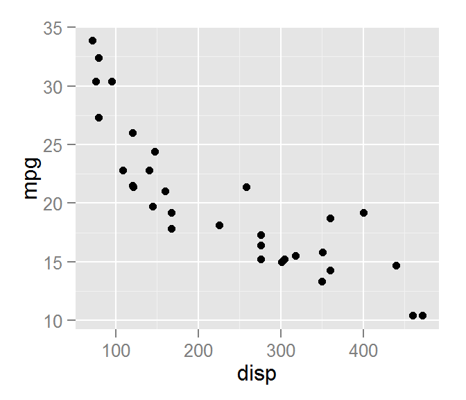

```r
require(ggplot2, quietly = T)
ggplot(mtcars, aes_string(x = "disp", y = "mpg")) +
    geom_point()
```

This way, we can make a function for scatterplots where we pass an arbitrary data.frame and the `x` and `y` arguments are whatever column names we want.

```r
make_gg_scatter <- function(data, x, y, print = T) {
    gg <- ggplot(data, aes_string(x = x, y = y)) +
        geom_point()
    if (print) print(gg)
    return(gg)
}
```

# User-Friendly Functions

# Package-Level documentation

- When someone type `?yourpackage`, show them something useful.
- Write examples in your function documentation.
- Write a vignette showing how your functions work together.

# Warnings, errors and messages

Errors stop code. With warnings, code still executes, but a special type of message is printed.

Good warnings and errors makes code much more user-friendly.

The standard commands are `stop` for an error, and `warning` for a warning. `stopifnot` is nice for code readability, and it automatically generates an error message based on the condition, which means you don’t have to write an error message by hand, but it might be more confusing to the user.

Messages (`message`) are for other types of messages, like what you see when some packages start, an optimization routine that updates you as you go along, etc.

Displaying data or results to the console should use `print` or `cat`.

```r
make_gg_scatter <- function(data, x, y, print = T) {
    if (!is.data.frame(data)) stop("data must be a data.frame")
    gg <- ggplot(data, aes_string(x = x, y = y)) +
        geom_point()
    if (print) print(gg)
    return(gg)
}
```

```r
make_gg_scatter <- function(data, x, y, print = T) {
    if (!is.data.frame(data)) stop("data must be a data.frame")
    stopifnot(x %in% names(data), y %in% names(data))
    gg <- ggplot(data, aes_string(x = x, y = y)) +
        geom_point()
    if (print) print(gg)
    return(gg)
}
```

```r
make_gg_scatter <- function(data, x, y, print = T) {
    if (!is.data.frame(data)) stop("data must be a data.frame")
    stopifnot(x %in% names(data), y %in% names(data))
    gg <- ggplot(data, aes_string(x = x, y = y)) +
        geom_point()
    if (print) {
        print(gg)
        message("Plot printed.")
    } else warning("Plot not printed.")
    return(gg)
}
```

# Working around errors

Sometimes you want to try something in a script, but if it does not work you don’t want your whole script to stop. You can wrap expressions in `try` or `tryCatch` to do this.

There’s a beautiful example of this written up on [Stack Overflow](http://stackoverflow.com/a/12195574/903061). It’s better than any documentation I’ve seen.

# Argument Matching

Sometimes one argument several possibilities that could be specified by the user. (Like `method` in `optim()`, or `breaks` in `hist()`.) You can use `match.arg()` inside your function so users can partially fill out the choice, rather than needing to type out `hist(rnorm(100), breaks = "freedman-diaconis")`.